# 산업공학특론I_13-14주차_산업데이터분석

2024-05-29

## [데이터 분석 개요]

### 1. 대상 데이터: 다단계 공정 데이터셋

(https://www.kaggle.com/datasets/supergus/multistage-continuousflow-manufacturing-process)

미시간 주 디트로이트 근처의 실제 생산 라인 내에서 여러 위치, 여러 생산 라인에 대하여 계측한 데이터

다양한 입력 데이터로부터 라인의 출력 특정 속성을 예측하기 위한 목적으로 수집

해당 공정 라인은 병렬 및 직렬 단계로 구성된 고속 연속 제조 공정으로, 다음과 같은 구조를 가짐

- Stage 1에서는 M1, M2, M3 기계가 병렬로 작동하며, 이들의 출력이 결합기로 전달
- 결합기에서 출력되는 Stage 1에 대한 예측치는 제작된 제품의 외부 표면을 둘러싼 15개의 위치에서 측정
- 다음으로, M4와 M5가 직렬로 처리하는 Stage 2로 이동
- M5 작동 후에는 동일한 15개의 위치에 대한 Stage 2의 측정이 이루어짐

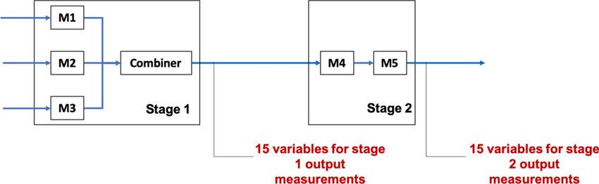

* Oleghe, O. (2020). A predictive noise correction methodology for manufacturing process datasets. Journal of Big Data, 7(1), 89.

### 2. 분석 절차

데이터 탐색 및 전처리 / 특징 추출 및 차원 축소 / 모델 학습 및 평가 순서로 3단계로 나누어 분석 진행

2단계 공정인 관계로 Stage 1에 대한 예측모델, Stage 2에 대한 예측모델을 2단계로 모델링할 것 (이 때, Stage 2의 결과는 Stage 1에 영향을 받음)

원래 Stage 1, Stage 2에 대한 예측값은 각각 15개씩이지만, 본 강의에서는 다변량 예측을 다루지 않는 관계로 각 Stage에 대한 평균값을 종속변수로 설정

팀별로 작업을 수행하며, 작업 코드는 팀장의 Github에 Push하여 공유, 통찰력 있는 분석 기법 발굴 시 모두와 공유

가이드로 제공된 참고문헌을 바탕으로 다양한 방법론으로 분석을 수행

## [데이터 분석]

### 1. 데이터 탐색 및 전처리

- 데이터의 전반적인 분포, 특징을 파악하기 위한 기초 분석 진행
- 다양한 전처리 방법론을 활용하여 데이터를 정제 (e.g. 필요없는 변수 및 이상치/노이즈 제거 또는 보정, 표준화 등)
- 데이터 전처리 순서 (학습, 테스트셋 분할 전후)를 꼼꼼히 살펴보고 진행할 것

```r
dat <- read.csv('산업공학특론I_13-14주차_데이터.csv')
head(dat)
dim(dat)

# timestamp 변수 삭제
dat <- dat[,-1]

# unique값 적은 변수 살펴보기
uniqval <- function(x){length(unique(x))}
dat_uniq <- apply(dat,2,uniqval)
apply(dat[,dat_uniq<10], 2, unique)

# setpoint 관련 변수를 면밀히 조사
setidx <- grep('Setpoint', colnames(dat))

par(mfrow=c(3,5))
for (idx in setidx){
  plot(dat[,idx-1], dat[,idx], xlab=colnames(dat)[idx-1], ylab=colnames(dat)[idx])
}
apply(dat[,setidx], 2, table)
dat_set0 <- dat[dat[,setidx[1]]==0, ]
apply(dat_set0[,setidx], 2, table) # 0 제외 시 단일값 확인

# 이상치 제거 (제거 대신 다른 방법을 쓸 수도 있음)
dat <- dat[dat[,setidx[1]]!=0, ]
apply(dat[,setidx],2,uniqval)

# Setpoint 변수 삭제
dat <- dat[,-setidx]

# 다변량 회귀분석이 아닌 관계로 종속변수 평균화
depidx1 <- grep('Stage1.Output', colnames(dat))
depidx2 <- grep('Stage2.Output', colnames(dat))
dat$Stage1_Output <- apply(dat[,depidx1],1,mean)
dat$Stage2_Output <- apply(dat[,depidx2],1,mean)
dat <- dat[,-c(depidx1,depidx2)]
head(dat)


# 종속변수 기반 이상치 제거/보정
library(MASS)
outlier <- function(target){ # 방법 1) IQR
  iqr <- quantile(target, c(0.25, 0.75))
  (target < iqr[1] - 1.5 * diff(iqr))|(target > iqr[2] + 1.5 * diff(iqr))
}
outlier <- function(target){ # 방법 2) z-score
  z <- (target - mean(target)) / sd(target)
  abs(z) > 3
}
outlier <- function(target){ # 방법 3) Cook's distance
  temp <- dat[,-((ncol(dat)-1):ncol(dat))]
  temp <- cbind(temp, target)
  reg <- lm(target ~ ., data=temp)
  cd <- cooks.distance(reg)
  cd > 4 / (nrow(temp) - length(reg$coef))
}

### 1. 이상치 제거
dat <- dat[!(outlier(dat$Stage1_Output) & outlier(dat$Stage2_Output)),]

### 2. 이상치 보정 (평균치 또는 중앙값)
# dat[(outlier(dat$Stage1_Output) & outlier(dat$Stage2_Output)),] <- apply(dat[!(outlier(dat$Stage1_Output) & outlier(dat$Stage2_Output)),],2,mean)
# apply(dat[!(outlier(dat$Stage1_Output) & outlier(dat$Stage2_Output)),],2,median)


# 변수명 변경
colnames(dat) <- gsub('.C[.]Actual','',colnames(dat))
colnames(dat) <- gsub('.U[.]Actual','',colnames(dat))
colnames(dat) <- gsub('[.]','_',colnames(dat))
colnames(dat) <- gsub('Machine','M',colnames(dat))
colnames(dat)


# 트레인, 테스트셋 분할
library(caret)
set.seed(0)
trainidx <- sample(1:nrow(dat), 0.7*nrow(dat))
trainset <- dat[trainidx,]
testset <- dat[-trainidx,]

# 표준화
depidx <- (ncol(trainset)-1):ncol(trainset)
scaling <- preProcess(trainset[, -depidx], method = c("center", "scale"))

traintarget <- trainset[,depidx]
trainsc <- predict(scaling, trainset[, -depidx])
trainsc <- cbind(trainsc, traintarget)

testtarget <- testset[,depidx]
testsc <- predict(scaling, testset[, -depidx])
testsc <- cbind(testsc, testtarget)

# 상관분석
library(corrplot)
par(mfrow=c(1,1))
corr <- cor(trainsc)
col <- colorRampPalette(c('white','blue'))
corrplot(abs(corr), method='color', col=col(200), type='upper',tl.cex = 0.5, tl.col='black')

# 공정별 데이터셋 정의
### Stage1의 경우 1차 공정 변수만 활용하기 때문에 별도로 변수 추출
colnames(trainsc)
extract <- function(data, type){
  if (type==1){ data[,c(1:41,56)] } else if (type==2) { data[,-56] }
}

trainsc1 <- extract(trainsc,1); trainsc2 <- extract(trainsc,2)
testsc1 <- extract(testsc,1); testsc2 <- extract(testsc,2)
```

### 2. 특징 추출 및 차원 축소

- 전처리가 이루어진 데이터로부터 특성을 재정의하거나 차원 축소 기법을 적용
- 신규 변수 또는 축소된 차원으로 효과적인 예측을 수행하기 위한 방안 도출

```r
library(caret)
trainsc1 <- read.csv('train_Stage1.csv')
trainsc2 <- read.csv('train_Stage2.csv')
testsc1 <- read.csv('test_Stage1.csv')
testsc2 <- read.csv('test_Stage2.csv')



#######
# PCA #
#######

### Stage1
pca1 <- prcomp(trainsc1[, -ncol(trainsc1)])
summary(pca1) #최적 주성분 12개
```

```
## Importance of components:
##                           PC1    PC2     PC3     PC4     PC5     PC6     PC7
## Standard deviation     3.5739 2.3838 1.83209 1.54366 1.28208 1.15060 1.06032
## Proportion of Variance 0.3115 0.1386 0.08187 0.05812 0.04009 0.03229 0.02742
## Cumulative Proportion  0.3115 0.4501 0.53199 0.59011 0.63020 0.66249 0.68991
##                            PC8     PC9    PC10    PC11    PC12    PC13    PC14
## Standard deviation     1.03408 1.01336 1.00966 1.00107 0.98808 0.95951 0.93904
## Proportion of Variance 0.02608 0.02505 0.02486 0.02444 0.02381 0.02245 0.02151
## Cumulative Proportion  0.71599 0.74104 0.76590 0.79035 0.81416 0.83661 0.85812
##                           PC15    PC16    PC17    PC18   PC19    PC20    PC21
## Standard deviation     0.90538 0.88869 0.82178 0.81427 0.7684 0.70516 0.60353
## Proportion of Variance 0.01999 0.01926 0.01647 0.01617 0.0144 0.01213 0.00888
## Cumulative Proportion  0.87811 0.89738 0.91385 0.93002 0.9444 0.95655 0.96543
##                           PC22    PC23    PC24    PC25    PC26    PC27    PC28
## Standard deviation     0.58847 0.50952 0.40121 0.39917 0.37591 0.30458 0.24532
## Proportion of Variance 0.00845 0.00633 0.00393 0.00389 0.00345 0.00226 0.00147
## Cumulative Proportion  0.97388 0.98021 0.98414 0.98803 0.99147 0.99373 0.99520
##                           PC29    PC30    PC31    PC32    PC33    PC34    PC35
## Standard deviation     0.21790 0.21113 0.18024 0.17043 0.13332 0.11313 0.10812
## Proportion of Variance 0.00116 0.00109 0.00079 0.00071 0.00043 0.00031 0.00029
## Cumulative Proportion  0.99636 0.99745 0.99824 0.99895 0.99938 0.99969 0.99998
##                           PC36     PC37      PC38      PC39     PC40      PC41
## Standard deviation     0.02916 2.24e-14 7.948e-15 1.578e-15 1.17e-15 3.194e-16
## Proportion of Variance 0.00002 0.00e+00 0.000e+00 0.000e+00 0.00e+00 0.000e+00
## Cumulative Proportion  1.00000 1.00e+00 1.000e+00 1.000e+00 1.00e+00 1.000e+00
```

```r
pca1 <- preProcess(trainsc1[, -ncol(trainsc1)], method = 'pca')
trainpca1 <- predict(pca1, trainsc1[,-ncol(trainsc1)])[,1:12]
trainpca1 <- cbind(trainpca1, trainsc1[,ncol(trainsc1)])

testpca1 <- predict(pca1, testsc1[,-ncol(testsc1)])[,1:12]
testpca1 <- cbind(testpca1, testsc1[,ncol(testsc1)])

colnames(trainpca1)[ncol(trainpca1)] <- colnames(testpca1)[ncol(testpca1)] <- 'Stage1_Output'


### Stage2
pca2 <- prcomp(trainsc2[, -ncol(trainsc2)])
summary(pca2) #최적 주성분 14개
```

```
## Importance of components:
##                          PC1    PC2     PC3     PC4     PC5     PC6     PC7
## Standard deviation     4.001 2.7265 2.10221 1.83215 1.42246 1.37455 1.17715
## Proportion of Variance 0.291 0.1352 0.08035 0.06103 0.03679 0.03435 0.02519
## Cumulative Proportion  0.291 0.4261 0.50649 0.56753 0.60432 0.63867 0.66386
##                           PC8     PC9    PC10    PC11    PC12    PC13    PC14
## Standard deviation     1.1175 1.07692 1.07272 1.02828 1.01897 1.01066 1.00125
## Proportion of Variance 0.0227 0.02109 0.02092 0.01922 0.01888 0.01857 0.01823
## Cumulative Proportion  0.6866 0.70765 0.72857 0.74780 0.76668 0.78525 0.80348
##                           PC15    PC16   PC17    PC18    PC19    PC20   PC21
## Standard deviation     0.99190 0.95466 0.9469 0.91778 0.88317 0.86655 0.8522
## Proportion of Variance 0.01789 0.01657 0.0163 0.01531 0.01418 0.01365 0.0132
## Cumulative Proportion  0.82136 0.83794 0.8542 0.86955 0.88373 0.89739 0.9106
##                           PC22    PC23    PC24    PC25    PC26    PC27    PC28
## Standard deviation     0.81553 0.79115 0.77938 0.69107 0.64815 0.59920 0.54352
## Proportion of Variance 0.01209 0.01138 0.01104 0.00868 0.00764 0.00653 0.00537
## Cumulative Proportion  0.92268 0.93406 0.94511 0.95379 0.96143 0.96796 0.97333
##                           PC29    PC30    PC31    PC32    PC33    PC34    PC35
## Standard deviation     0.47931 0.43302 0.40414 0.39521 0.37438 0.33414 0.29853
## Proportion of Variance 0.00418 0.00341 0.00297 0.00284 0.00255 0.00203 0.00162
## Cumulative Proportion  0.97750 0.98091 0.98388 0.98672 0.98927 0.99130 0.99292
##                           PC36    PC37    PC38    PC39    PC40    PC41    PC42
## Standard deviation     0.26900 0.25112 0.21684 0.21277 0.19142 0.18431 0.15095
## Proportion of Variance 0.00132 0.00115 0.00085 0.00082 0.00067 0.00062 0.00041
## Cumulative Proportion  0.99424 0.99538 0.99624 0.99706 0.99773 0.99835 0.99876
##                           PC43    PC44    PC45    PC46    PC47    PC48    PC49
## Standard deviation     0.13996 0.12137 0.11532 0.09412 0.09240 0.04908 0.02777
## Proportion of Variance 0.00036 0.00027 0.00024 0.00016 0.00016 0.00004 0.00001
## Cumulative Proportion  0.99912 0.99938 0.99963 0.99979 0.99994 0.99999 1.00000
##                             PC50      PC51      PC52      PC53      PC54
## Standard deviation     2.233e-14 7.946e-15 1.777e-15 1.237e-15 9.866e-16
## Proportion of Variance 0.000e+00 0.000e+00 0.000e+00 0.000e+00 0.000e+00
## Cumulative Proportion  1.000e+00 1.000e+00 1.000e+00 1.000e+00 1.000e+00
##                             PC55
## Standard deviation     3.343e-16
## Proportion of Variance 0.000e+00
## Cumulative Proportion  1.000e+00
```

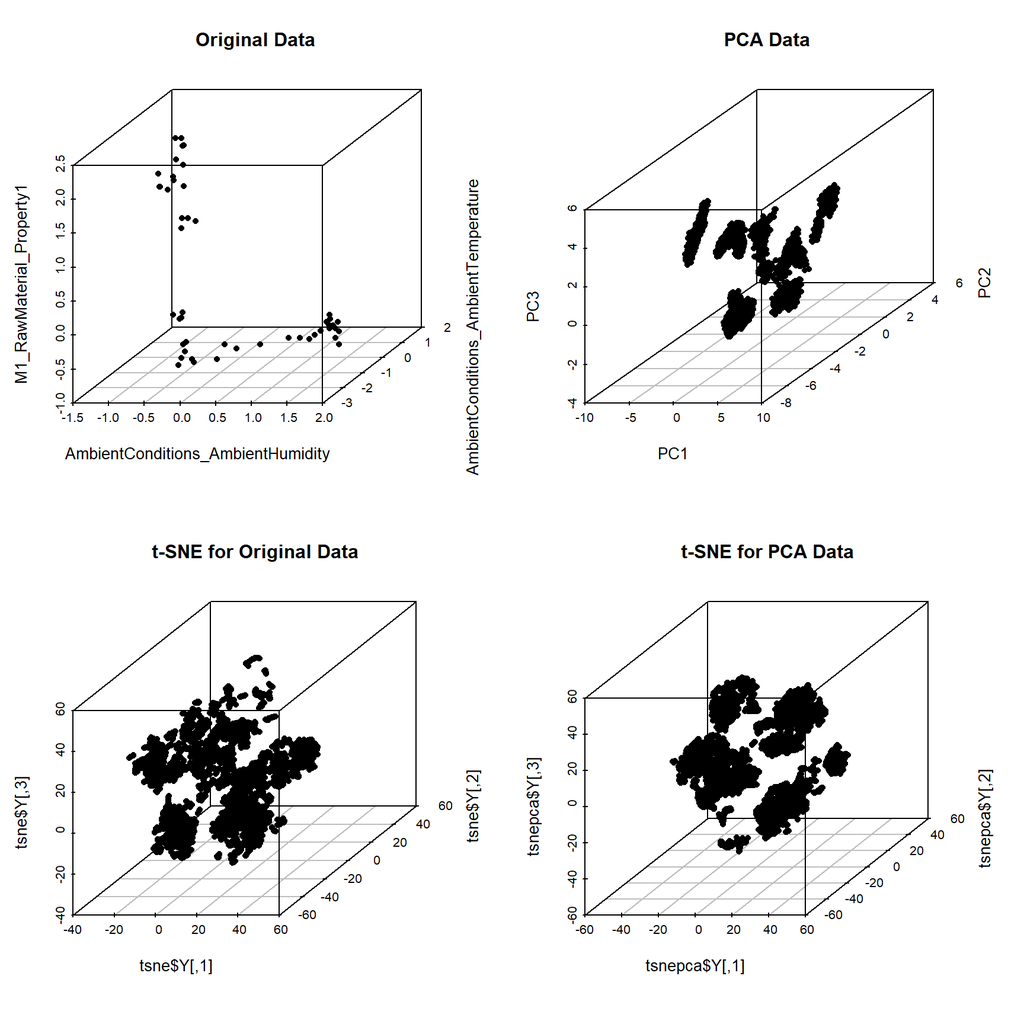

```r
pca2 <- preProcess(trainsc2[, -ncol(trainsc2)], method = 'pca')
trainpca2 <- predict(pca2, trainsc2[,-ncol(trainsc2)])[,1:14]
trainpca2 <- cbind(trainpca2, trainsc2[,ncol(trainsc2)])

testpca2 <- predict(pca2, testsc2[,-ncol(testsc2)])[,1:14]
testpca2 <- cbind(testpca2, testsc2[,ncol(testsc2)])

colnames(trainpca2)[ncol(trainpca2)] <- colnames(testpca2)[ncol(testpca2)] <- 'Stage2_Output'



#########
# t-SNE #
#########

library(Rtsne); library(scatterplot3d)
par(mfrow=c(2,2))

scatterplot3d(trainsc1[,1:3], pch=16, main = "Original Data")

scatterplot3d(trainpca1[,1:3], pch=16, main = "PCA Data")

tsne <- Rtsne(trainsc1[!duplicated(trainsc1),-ncol(trainsc1)], dims = 3)
scatterplot3d(tsne$Y, pch=16, main = "t-SNE for Original Data")

tsnepca <- Rtsne(trainpca1[!duplicated(trainpca1),-ncol(trainpca1)], dims = 3)
scatterplot3d(tsnepca$Y, pch=16, main = "t-SNE for PCA Data")
```

### 3. 모델 학습 및 평가

- Stage 1, Stage 2에 대한 예측 모델을 수립할 것
- 이 때, 각 Stage는 연결되어 있으며 Stage 2는 Stage 1의 영향을 받음

```r
###########
# Stage 1 #
###########

train_cv <- trainControl(method = "cv", number = 10)
library(Metrics)
evaluate <- function(actual,pred){
  result <- c(mae(actual,pred), mse(actual,pred), rmse(actual,pred))
  names(result) <- c('MAE','MSE','RMSE')
  print(result)
}

# 다중회귀분석
reg1 <- lm(Stage1_Output ~., data=trainsc1)
reg1_1 <- step(reg1, direction='forward', trace=F)
reg1_2 <- step(reg1, direction='backward', trace=F)
reg1_3 <- step(reg1, direction='both', trace=F)
summary(reg1_3)
```

```
##
## Call:
## lm(formula = Stage1_Output ~ AmbientConditions_AmbientTemperature +
##     M1_RawMaterial_Property1 + M1_RawMaterial_Property2 + M1_RawMaterial_Property3 +
##     M1_RawMaterial_Property4 + M1_RawMaterialFeederParameter +
##     M1_Zone1Temperature + M1_MotorAmperage + M1_MotorRPM + M1_MaterialPressure +
##     M1_ExitZoneTemperature + M2_RawMaterial_Property1 + M2_RawMaterialFeederParameter +
##     M2_Zone1Temperature + M2_Zone2Temperature + M2_MaterialPressure +
##     M2_MaterialTemperature + M3_RawMaterial_Property1 + M3_RawMaterial_Property2 +
##     M3_RawMaterialFeederParameter + M3_Zone1Temperature + M3_Zone2Temperature +
##     M3_MotorAmperage + M3_MotorRPM + M3_MaterialPressure + M3_MaterialTemperature +
##     FirstStage_CombinerOperation_Temperature1 + FirstStage_CombinerOperation_Temperature2,
##     data = trainsc1)
##
## Residuals:
##     Min      1Q  Median      3Q     Max
## -9.1861 -0.3860  0.1421  0.5879  3.4659
##
## Coefficients:
##                                            Estimate Std. Error  t value
## (Intercept)                               10.038015   0.009151 1096.947
## AmbientConditions_AmbientTemperature      -0.352542   0.022796  -15.465
## M1_RawMaterial_Property1                   0.330514   0.073174    4.517
## M1_RawMaterial_Property2                  -0.417695   0.145832   -2.864
## M1_RawMaterial_Property3                  -0.582312   0.118326   -4.921
## M1_RawMaterial_Property4                  -0.327519   0.070356   -4.655
## M1_RawMaterialFeederParameter             -0.062206   0.009718   -6.401
## M1_Zone1Temperature                        0.086116   0.012785    6.736
## M1_MotorAmperage                          -0.167393   0.024906   -6.721
## M1_MotorRPM                               -0.311047   0.051872   -5.996
## M1_MaterialPressure                        0.050419   0.032710    1.541
## M1_ExitZoneTemperature                    -0.144608   0.018721   -7.724
## M2_RawMaterial_Property1                  -0.375630   0.024705  -15.205
## M2_RawMaterialFeederParameter              0.023343   0.009816    2.378
## M2_Zone1Temperature                        0.036233   0.009690    3.739
## M2_Zone2Temperature                        0.020688   0.009670    2.139
## M2_MaterialPressure                        0.042671   0.012476    3.420
## M2_MaterialTemperature                     0.187590   0.040361    4.648
## M3_RawMaterial_Property1                  -1.577306   0.041090  -38.387
## M3_RawMaterial_Property2                  -1.766005   0.044336  -39.833
```

[output cut: 30 more lines]

```
## M3_RawMaterialFeederParameter             0.084159 .
## M3_Zone1Temperature                        < 2e-16 ***
## M3_Zone2Temperature                       0.014610 *
## M3_MotorAmperage                          0.018545 *
## M3_MotorRPM                               1.22e-09 ***
## M3_MaterialPressure                        < 2e-16 ***
## M3_MaterialTemperature                     < 2e-16 ***
## FirstStage_CombinerOperation_Temperature1 6.38e-08 ***
## FirstStage_CombinerOperation_Temperature2 0.000864 ***
## ---
## Signif. codes:  0 '***' 0.001 '**' 0.01 '*' 0.05 '.' 0.1 ' ' 1
##
## Residual standard error: 0.9041 on 9733 degrees of freedom
## Multiple R-squared:  0.4019, Adjusted R-squared:  0.4002
## F-statistic: 233.6 on 28 and 9733 DF,  p-value: < 2.2e-16
```

```r
evaluate(testsc1$Stage1_Output, predict(reg1, testsc1))
```

```
##       MAE       MSE      RMSE
## 0.6290591 0.8658728 0.9305228
```

```r
evaluate(testsc1$Stage1_Output, predict(reg1_3, testsc1)) ###
```

```
##       MAE       MSE      RMSE
## 0.6290474 0.8657592 0.9304618
```

```r
reg1_pc <- lm(Stage1_Output ~., data=trainpca1)
reg1_pc1 <- step(reg1_pc, direction='forward', trace=F)
reg1_pc2 <- step(reg1_pc, direction='backward', trace=F)
reg1_pc3 <- step(reg1_pc, direction='both', trace=F)
summary(reg1_pc)
```

```
##
## Call:
## lm(formula = Stage1_Output ~ ., data = trainpca1)
##
## Residuals:
##     Min      1Q  Median      3Q     Max
## -9.7562 -0.3850  0.1271  0.7351  2.0572
##
## Coefficients:
##              Estimate Std. Error t value Pr(>|t|)
## (Intercept) 10.038015   0.010627 944.588  < 2e-16 ***
## PC1          0.106407   0.002974  35.784  < 2e-16 ***
## PC2          0.013786   0.004458   3.092  0.00199 **
## PC3          0.112380   0.005801  19.373  < 2e-16 ***
## PC4         -0.053243   0.006885  -7.734 1.15e-14 ***
## PC5         -0.163931   0.008289 -19.776  < 2e-16 ***
## PC6         -0.017946   0.009236  -1.943  0.05204 .
## PC7          0.059004   0.010023   5.887 4.06e-09 ***
## PC8          0.115344   0.010277  11.223  < 2e-16 ***
## PC9         -0.034220   0.010487  -3.263  0.00111 **
## PC10         0.014098   0.010526   1.339  0.18047
## PC11         0.004836   0.010616   0.456  0.64876
## PC12         0.053300   0.010756   4.956 7.34e-07 ***
## ---
## Signif. codes:  0 '***' 0.001 '**' 0.01 '*' 0.05 '.' 0.1 ' ' 1
##
## Residual standard error: 1.05 on 9749 degrees of freedom
## Multiple R-squared:  0.1921, Adjusted R-squared:  0.1911
## F-statistic: 193.2 on 12 and 9749 DF,  p-value: < 2.2e-16
```

```r
evaluate(testsc1$Stage1_Output, predict(reg1_pc, testpca1))
```

```
##       MAE       MSE      RMSE
## 0.7194516 1.1614117 1.0776881
```

```r
# 정규화 회귀분석
library(glmnet)
```

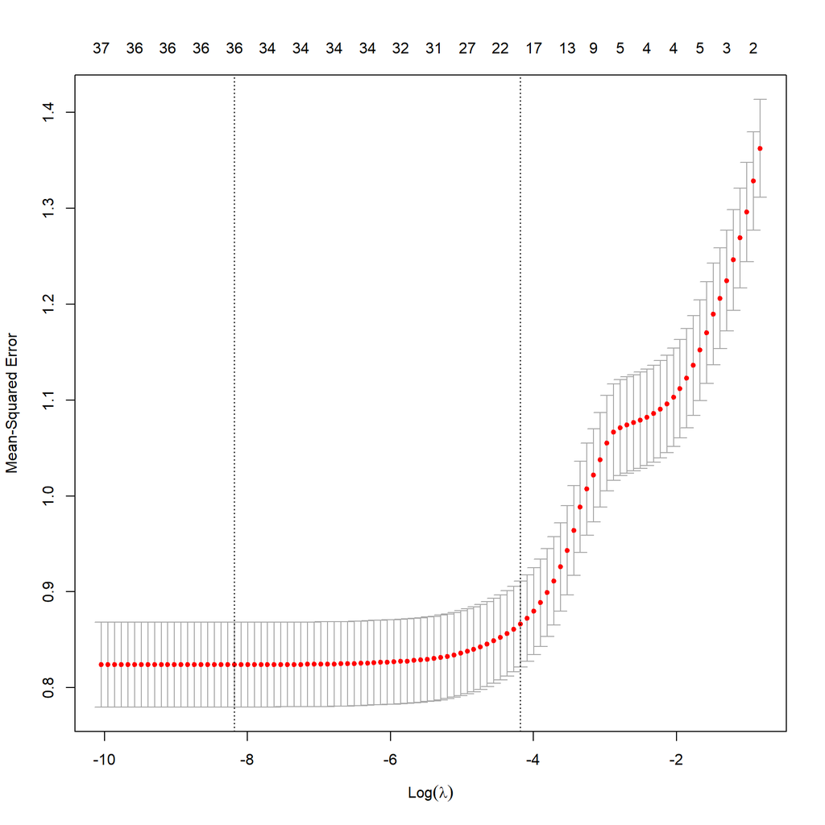

```r
regglm <- function(train, alpha){
  x <- as.matrix(train[,-ncol(train)]); y <- as.matrix(train[,ncol(train)])
  model <- cv.glmnet(x,y, alpha=alpha)
  plot(model)
  return(model)
}

evalglm <- function(model, test){
  pred <- predict(model, as.matrix(test[,-ncol(test)]))
  evaluate(test[,ncol(test)], pred)
}

lasso1 <- regglm(trainsc1, 1)
```

```r
ridge1 <- regglm(trainsc1, 0)
```

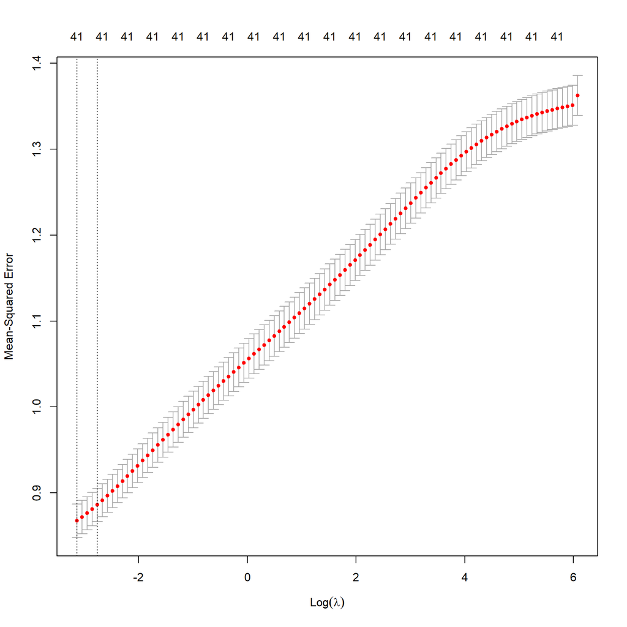

```r
elastic1 <- regglm(trainsc1, 0.5)
```

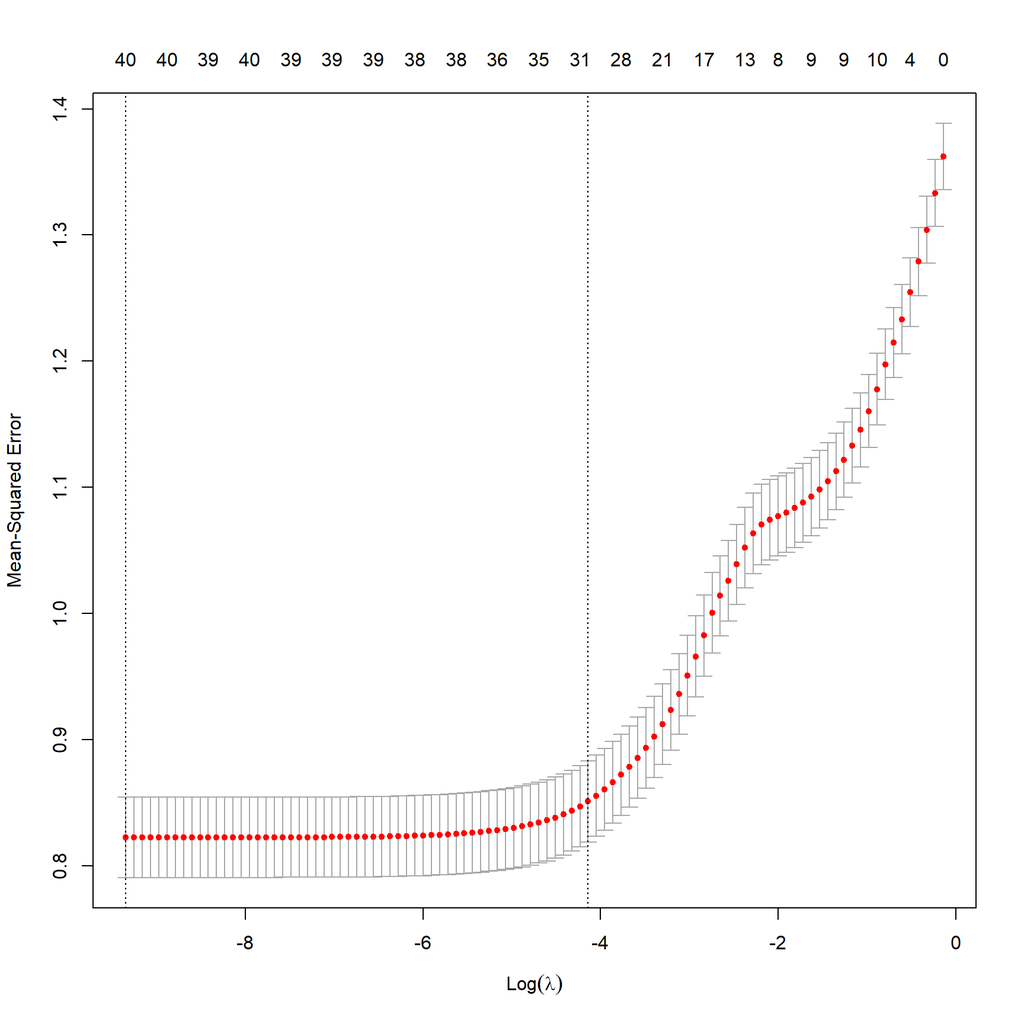

```r
evalglm(lasso1, testsc1)
```

```
##       MAE       MSE      RMSE
## 0.6555661 0.9085207 0.9531635
```

```r
evalglm(ridge1, testsc1)
```

```
##       MAE       MSE      RMSE
## 0.6630037 0.9294537 0.9640818
```

```r
evalglm(elastic1, testsc1) ###
```

```
##       MAE       MSE      RMSE
## 0.6458614 0.8931862 0.9450853
```

```r
lasso_pc1 <- regglm(trainpca1, 1)
```

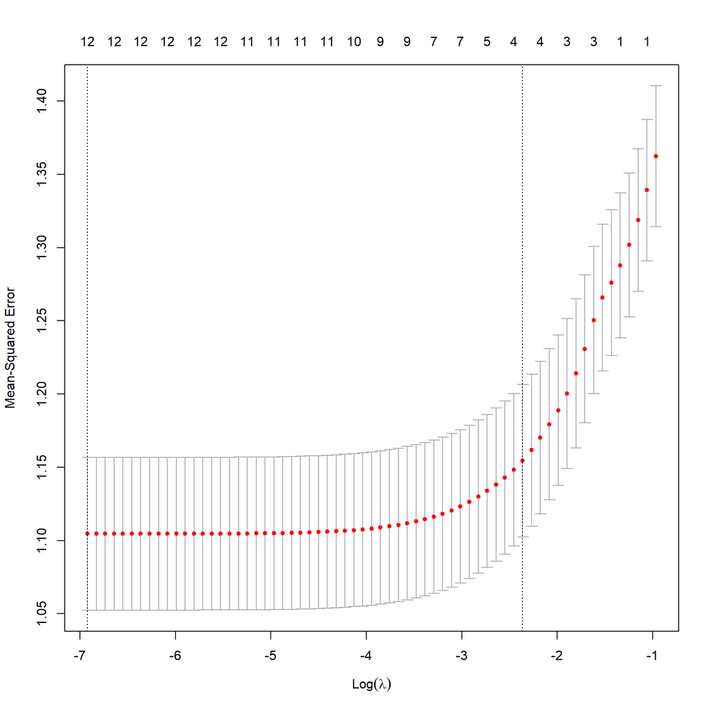

```r
ridge_pc1 <- regglm(trainpca1, 0)
```

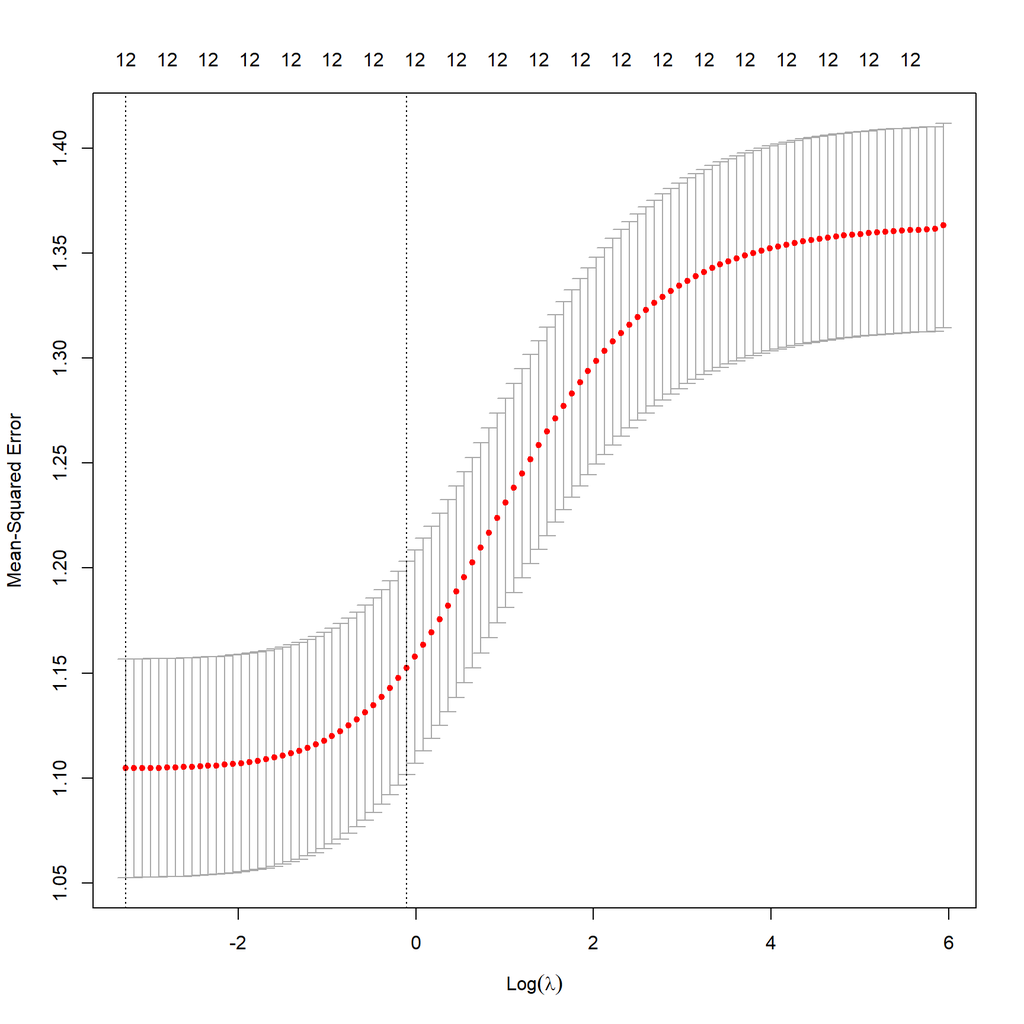

```r
elastic_pc1 <- regglm(trainpca1, 0.5)
```

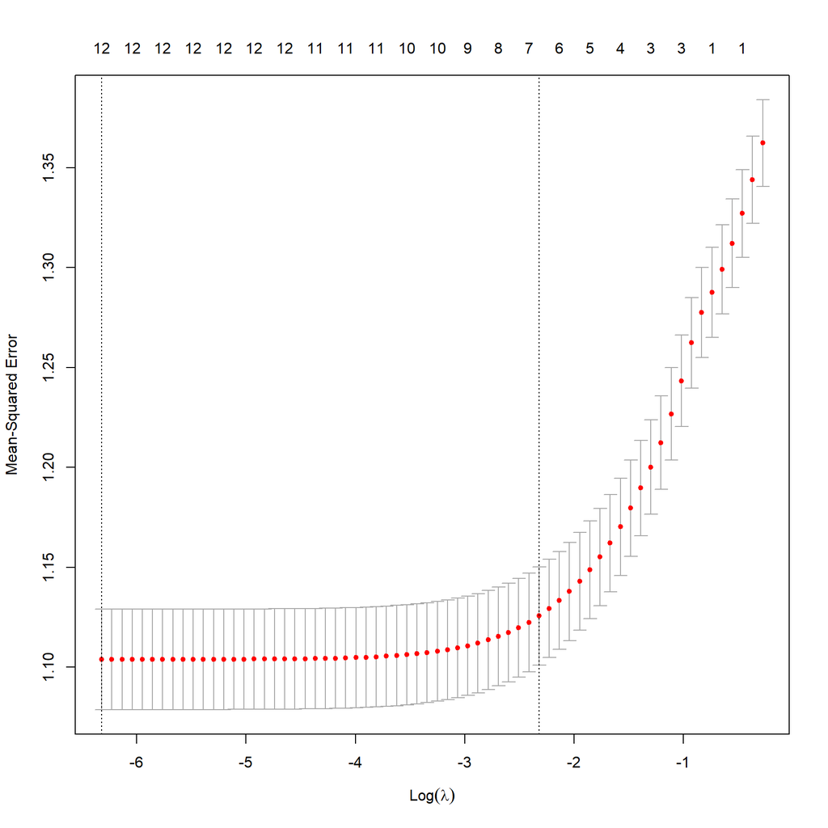

```r
evalglm(lasso_pc1, testpca1)
```

```
##       MAE       MSE      RMSE
## 0.7767022 1.2068669 1.0985749
```

```r
evalglm(ridge_pc1, testpca1)
```

```
##       MAE       MSE      RMSE
## 0.7829691 1.2064530 1.0983866
```

```r
evalglm(elastic_pc1, testpca1)
```

```
##       MAE       MSE      RMSE
## 0.7541315 1.1802854 1.0864094
```

```r
###########
# Stage 2 #
###########

# 예측값 합산
output1 <- predict(reg1_3, trainsc1)
trainsc2 <- cbind(trainsc2, output1)

output1 <- predict(reg1_3, testsc1)
testsc2 <- cbind(testsc2, output1)

# 다중회귀분석
reg2 <- lm(Stage2_Output ~., data=trainsc2)
summary(reg2)
```

```
##
## Call:
## lm(formula = Stage2_Output ~ ., data = trainsc2)
##
## Residuals:
##     Min      1Q  Median      3Q     Max
## -6.9343 -0.1962  0.0197  0.2232  4.3607
##
## Coefficients: (7 not defined because of singularities)
##                                            Estimate Std. Error  t value
## (Intercept)                                7.519599   0.006971 1078.704
## AmbientConditions_AmbientHumidity         -1.256684   0.074690  -16.825
## AmbientConditions_AmbientTemperature      -0.136109   0.031191   -4.364
## M1_RawMaterial_Property1                   0.657308   0.083168    7.903
## M1_RawMaterial_Property2                  -1.278183   0.179396   -7.125
## M1_RawMaterial_Property3                  -0.973622   0.145604   -6.687
## M1_RawMaterial_Property4                  -0.252534   0.064694   -3.904
## M1_RawMaterialFeederParameter             -0.005201   0.007619   -0.683
## M1_Zone1Temperature                       -0.171751   0.011607  -14.797
## M1_Zone2Temperature                        0.018057   0.007358    2.454
## M1_MotorAmperage                          -0.057879   0.022460   -2.577
## M1_MotorRPM                               -0.562023   0.047696  -11.783
## M1_MaterialPressure                        0.142823   0.028547    5.003
## M1_MaterialTemperature                     0.104228   0.035371    2.947
## M1_ExitZoneTemperature                    -0.059809   0.017609   -3.396
## M2_RawMaterial_Property1                  -0.472698   0.023838  -19.830
## M2_RawMaterial_Property2                         NA         NA       NA
## M2_RawMaterial_Property3                         NA         NA       NA
## M2_RawMaterial_Property4                         NA         NA       NA
## M2_RawMaterialFeederParameter              0.011820   0.007501    1.576
## M2_Zone1Temperature                       -0.004750   0.007501   -0.633
## M2_Zone2Temperature                       -0.021185   0.007536   -2.811
## M2_MotorAmperage                          -0.021252   0.011659   -1.823
## M2_MotorRPM                               -0.001410   0.007092   -0.199
## M2_MaterialPressure                        0.006510   0.009723    0.669
## M2_MaterialTemperature                    -0.091564   0.051670   -1.772
## M2_ExitZoneTemperature                    -0.001701   0.007011   -0.243
## M3_RawMaterial_Property1                   0.126251   0.032373    3.900
## M3_RawMaterial_Property2                  -0.150966   0.042564   -3.547
## M3_RawMaterial_Property3                         NA         NA       NA
```

[output cut: 76 more lines]

```
## M4_ExitTemperature                        1.14e-13 ***
## M5_Temperature1                           0.003757 **
## M5_Temperature2                           0.000557 ***
## M5_Temperature3                            < 2e-16 ***
## M5_Temperature4                           0.455187
## M5_Temperature5                           0.907798
## M5_Temperature6                           0.007170 **
## M5_ExitTemperature                         < 2e-16 ***
## output1                                         NA
## ---
## Signif. codes:  0 '***' 0.001 '**' 0.01 '*' 0.05 '.' 0.1 ' ' 1
##
## Residual standard error: 0.6888 on 9712 degrees of freedom
## Multiple R-squared:  0.7831, Adjusted R-squared:  0.782
## F-statistic: 715.7 on 49 and 9712 DF,  p-value: < 2.2e-16
```

```r
reg2_1 <- step(reg2, direction='forward', trace=F)
reg2_2 <- step(reg2, direction='backward', trace=F)
reg2_3 <- step(reg2, direction='both', trace=F)
summary(reg2_3)
```

```
##
## Call:
## lm(formula = Stage2_Output ~ AmbientConditions_AmbientHumidity +
##     AmbientConditions_AmbientTemperature + M1_RawMaterial_Property1 +
##     M1_RawMaterial_Property2 + M1_RawMaterial_Property3 + M1_RawMaterial_Property4 +
##     M1_Zone1Temperature + M1_Zone2Temperature + M1_MotorAmperage +
##     M1_MotorRPM + M1_MaterialPressure + M1_MaterialTemperature +
##     M1_ExitZoneTemperature + M2_RawMaterial_Property1 + M2_RawMaterialFeederParameter +
##     M2_Zone2Temperature + M2_MotorAmperage + M2_MaterialTemperature +
##     M3_RawMaterial_Property1 + M3_RawMaterial_Property2 + M3_Zone1Temperature +
##     M3_MotorRPM + M3_MaterialPressure + M3_ExitZoneTemperature +
##     FirstStage_CombinerOperation_Temperature1 + FirstStage_CombinerOperation_Temperature2 +
##     FirstStage_CombinerOperation_Temperature3 + M4_Temperature1 +
##     M4_Temperature2 + M4_Temperature3 + M4_Temperature5 + M4_ExitTemperature +
##     M5_Temperature1 + M5_Temperature2 + M5_Temperature3 + M5_Temperature6 +
##     M5_ExitTemperature, data = trainsc2)
##
## Residuals:
##     Min      1Q  Median      3Q     Max
## -6.9450 -0.1934  0.0195  0.2210  4.3733
##
## Coefficients:
##                                            Estimate Std. Error  t value
## (Intercept)                                7.519599   0.006969 1079.015
## AmbientConditions_AmbientHumidity         -1.262120   0.073743  -17.115
## AmbientConditions_AmbientTemperature      -0.129921   0.024726   -5.254
## M1_RawMaterial_Property1                   0.665877   0.080344    8.288
## M1_RawMaterial_Property2                  -1.306717   0.174334   -7.495
## M1_RawMaterial_Property3                  -0.989723   0.141114   -7.014
## M1_RawMaterial_Property4                  -0.249556   0.063323   -3.941
## M1_Zone1Temperature                       -0.170102   0.011533  -14.750
## M1_Zone2Temperature                        0.018665   0.007295    2.559
## M1_MotorAmperage                          -0.058939   0.022169   -2.659
## M1_MotorRPM                               -0.553571   0.046585  -11.883
## M1_MaterialPressure                        0.147415   0.027935    5.277
## M1_MaterialTemperature                     0.104110   0.033549    3.103
## M1_ExitZoneTemperature                    -0.061742   0.015598   -3.958
## M2_RawMaterial_Property1                  -0.486673   0.020722  -23.486
## M2_RawMaterialFeederParameter              0.014149   0.007099    1.993
## M2_Zone2Temperature                       -0.020998   0.007505   -2.798
```

[output cut: 51 more lines]

```
## M4_Temperature2                           0.002869 **
## M4_Temperature3                            < 2e-16 ***
## M4_Temperature5                           0.115310
## M4_ExitTemperature                        3.56e-14 ***
## M5_Temperature1                           0.003855 **
## M5_Temperature2                           0.000498 ***
## M5_Temperature3                            < 2e-16 ***
## M5_Temperature6                           0.012070 *
## M5_ExitTemperature                         < 2e-16 ***
## ---
## Signif. codes:  0 '***' 0.001 '**' 0.01 '*' 0.05 '.' 0.1 ' ' 1
##
## Residual standard error: 0.6886 on 9724 degrees of freedom
## Multiple R-squared:  0.783,  Adjusted R-squared:  0.7821
## F-statistic: 948.1 on 37 and 9724 DF,  p-value: < 2.2e-16
```

```r
evaluate(testsc2$Stage2_Output, predict(reg2, testsc2))
```

```
##       MAE       MSE      RMSE
## 0.4027690 0.4422415 0.6650124
```

```r
evaluate(testsc2$Stage2_Output, predict(reg2_3, testsc2)) ###
```

```
##       MAE       MSE      RMSE
## 0.4030839 0.4424286 0.6651531
```

```r
reg2_pc <- lm(Stage2_Output ~., data=trainpca2)
summary(reg2_pc)
```

```
##
## Call:
## lm(formula = Stage2_Output ~ ., data = trainpca2)
##
## Residuals:
##     Min      1Q  Median      3Q     Max
## -6.6210 -0.3951 -0.0159  0.3770  5.0748
##
## Coefficients:
##              Estimate Std. Error t value Pr(>|t|)
## (Intercept)  7.519599   0.008592 875.227  < 2e-16 ***
## PC1         -0.049703   0.002148 -23.142  < 2e-16 ***
## PC2          0.368952   0.003151 117.078  < 2e-16 ***
## PC3          0.234830   0.004087  57.456  < 2e-16 ***
## PC4          0.079891   0.004690  17.036  < 2e-16 ***
## PC5         -0.135217   0.006040 -22.386  < 2e-16 ***
## PC6          0.102247   0.006251  16.357  < 2e-16 ***
## PC7          0.073295   0.007299  10.042  < 2e-16 ***
## PC8         -0.174314   0.007689 -22.671  < 2e-16 ***
## PC9         -0.151203   0.007978 -18.952  < 2e-16 ***
## PC10        -0.042379   0.008010  -5.291 1.24e-07 ***
## PC11         0.069142   0.008356   8.275  < 2e-16 ***
## PC12        -0.038862   0.008432  -4.609 4.10e-06 ***
## PC13        -0.011196   0.008501  -1.317    0.188
## PC14        -0.051229   0.008581  -5.970 2.46e-09 ***
## ---
## Signif. codes:  0 '***' 0.001 '**' 0.01 '*' 0.05 '.' 0.1 ' ' 1
##
## Residual standard error: 0.8489 on 9747 degrees of freedom
## Multiple R-squared:  0.6694, Adjusted R-squared:  0.6689
## F-statistic:  1409 on 14 and 9747 DF,  p-value: < 2.2e-16
```

```r
reg2_pc1 <- step(reg2_pc, direction='forward', trace=F)
reg2_pc2 <- step(reg2_pc, direction='backward', trace=F)
reg2_pc3 <- step(reg2_pc, direction='both', trace=F)
evaluate(testsc2$Stage2_Output, predict(reg2_pc, testpca2))
```

```
##       MAE       MSE      RMSE
## 0.5661763 0.7031227 0.8385241
```

```r
# 정규화회귀분석
lasso2 <- regglm(trainsc2, 1)
```

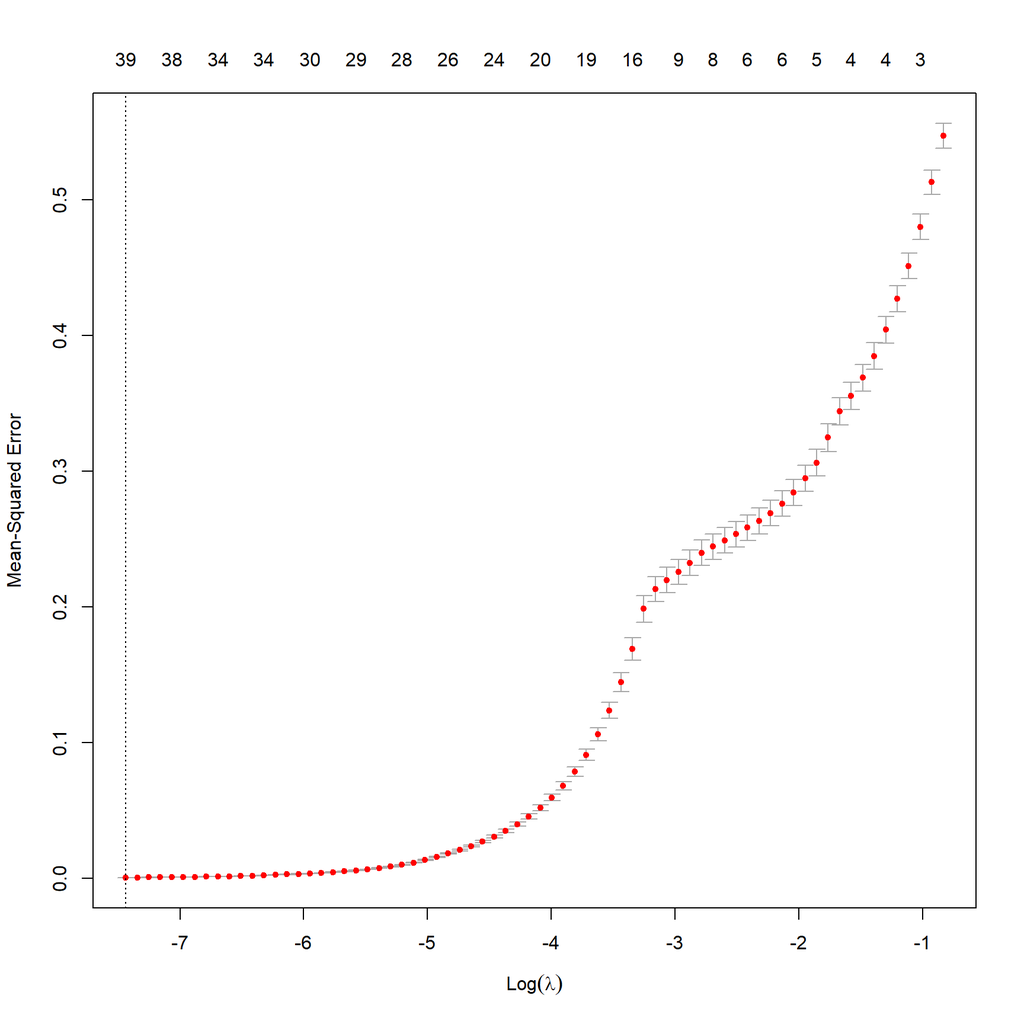

```r
ridge2 <- regglm(trainsc2, 0)
```

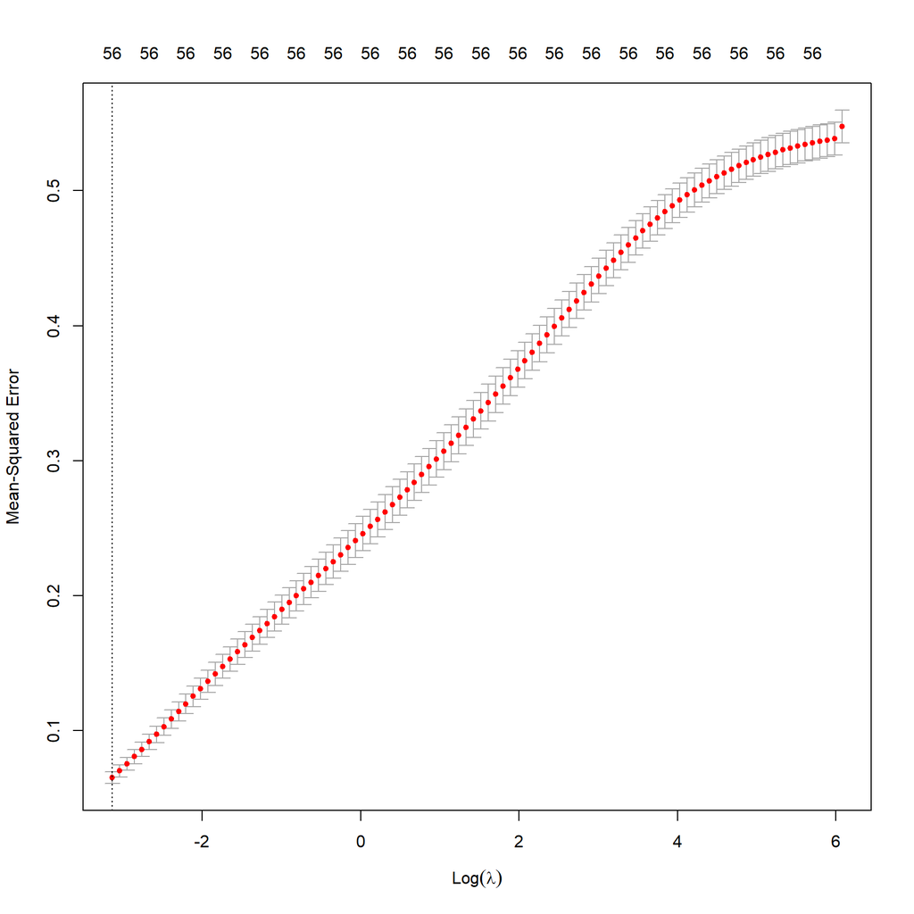

```r
elastic2 <- regglm(trainsc2, 0.5)
```

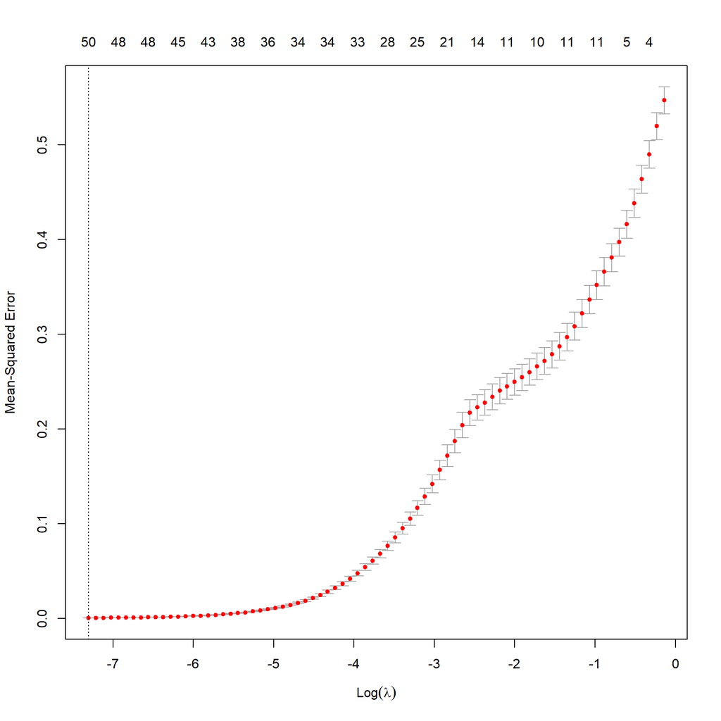

```r
evalglm(lasso2, testsc2)
```

```
##          MAE          MSE         RMSE
## 0.0162421273 0.0005321632 0.0230686627
```

```r
evalglm(ridge2, testsc2)
```

```
##        MAE        MSE       RMSE
## 0.13799540 0.06692981 0.25870796
```

```r
evalglm(elastic2, testsc2) ###
```

```
##          MAE          MSE         RMSE
## 0.0162040301 0.0005149735 0.0226930272
```

```r
lasso_pc2 <- regglm(trainpca2, 1)
```

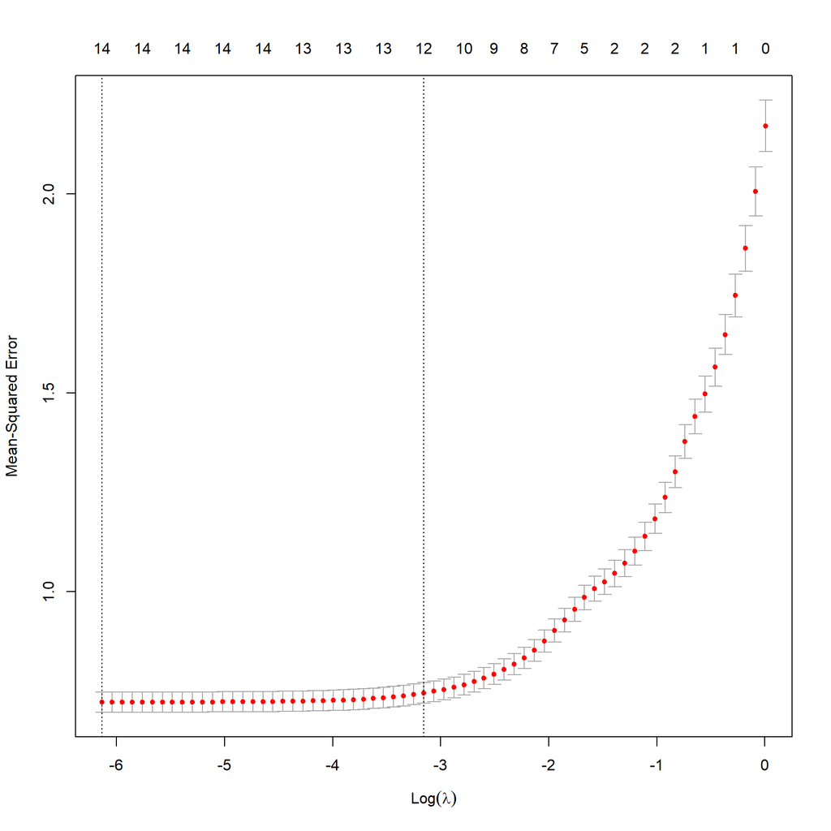

```r
ridge_pc2 <- regglm(trainpca2, 0)
```

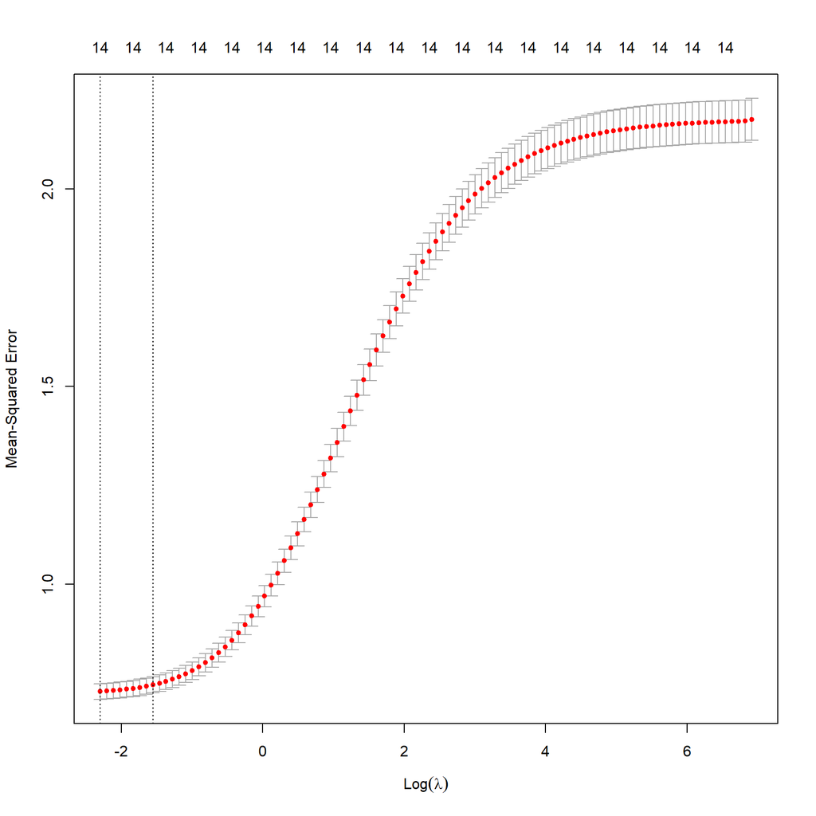

```r
elastic_pc2 <- regglm(trainpca2, 0.5)
```

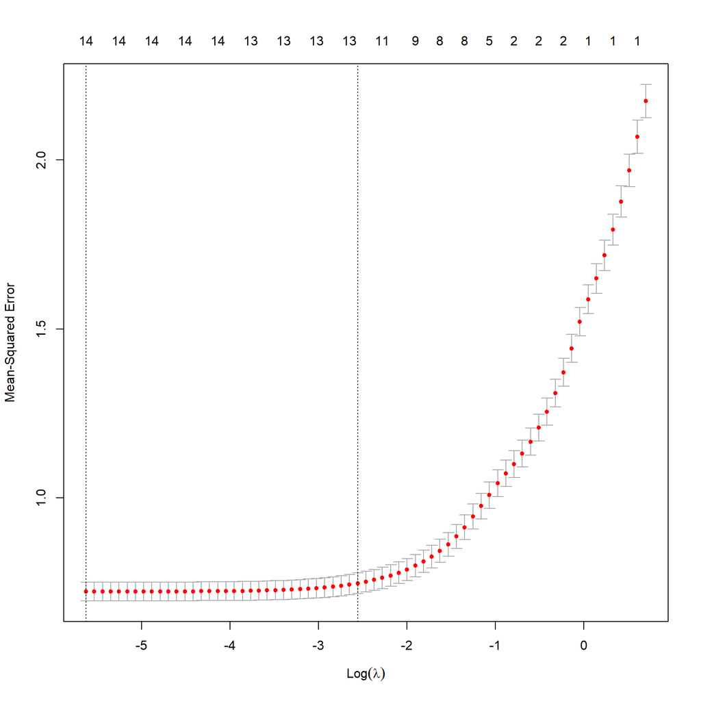

```r
evalglm(lasso_pc2, testpca2)
```

```
##       MAE       MSE      RMSE
## 0.5522982 0.7282479 0.8533744
```

```r
evalglm(ridge_pc2, testpca2)
```

```
##       MAE       MSE      RMSE
## 0.5634708 0.7322982 0.8557443
```

```r
evalglm(elastic_pc2, testpca2) ###
```

```
##       MAE       MSE      RMSE
## 0.5525462 0.7311904 0.8550967
```